# Modelling the impact of increasing sources using Bayesian, non-linear (power function) regressions

Author

Manikya Alister

```r
library(tidyverse)
library(posterior)
library(here)
library(ggdist)

# define experiments
experiments = c(1,2)

# load model fits
fits = list()
for (exp in experiments){
load(here(paste0("output/fe-brms-exp",exp,"-power-fit.Rdata")))
fits[[exp]] <- fit
}
```

There are a few reasons why I think modelling this kind of problem using non-linear regression, especially one that follows a power (or any asymptotic growth) function is useful. First, it has unique predictive value, allowing us to estimate how increasing the number of sources will increase confidence, even if we do not have direct empirical measurements for a given source number. This can therefore allow us to do things like predict when adding new sources will stop increasing confidence as a function of different types of consensus manipulations (e.g., independence), with minimal data.

Second, if there are differences in how independence (or any other manipulation, like expertise) affects the consensus X source number relationship, non-linear modelling like this allows us to make inferences about what is driving these differences. Using a power function, like I do here, we can infer whether source independence affects the rate at which confidence increases with multiple sources, whether it affects the highest possible confidence (asymptote) that increasing the number of sources will produce, or both. Therefore, I think doing this kind of analysis can provide added benefit beyond something like a mixed source number X independence ANOVA. That being said, you might not think the extra insights that can be gained by this approach are that important for the current study, which I would completely understand! I have been wanting to try this kind of analysis for a while, so it won’t have been a waste of time for me if we don’t end up using it.

# Evaluating model fit

Here, we can see whether the functional (power) form, describes the relationship between confidence and number of sources for both independence types.

```r
d_predictions <- NULL
d_empirical_summ <- NULL

for (exp in experiments) {

  # get predictions from estimated parameters for each experiment and load actual experiment data for each experiment

  fit <- fits[[exp]]

  # Make a prediction grid that spans all values of n_sources for both consensus types
new_data <- expand.grid(
  n_sources = seq(1, 10, length.out = 50),
  consensus = c("dependent", "independent")
) %>%
  as_tibble()

# Predict using fixed effects only (no partial pooling)
  d_predictions_exp  <- fitted(fit, newdata = new_data, re_formula = NA) %>%
  as_tibble() %>%
  bind_cols(new_data) %>%
  mutate(
    additional_sources = n_sources - 1,
    experiment = exp
  )

  d_predictions <- bind_rows(d_predictions, d_predictions_exp)


  # load and combine empirical data
  d_exp <- read.csv(here(
    paste0(
      "data/experiment-",
      exp,
      "/clean/con_rep_Exp",
      exp,
      "_cogsci.csv"
    )
  )) %>%
    mutate(
      n_sources = case_when(
        repetitions == "Baseline" ~ 1,
        repetitions == "Phase 1" ~ 4,
        repetitions == "Phase 2" ~ 7,
        repetitions == "Phase 3" ~ 10
      )
    )

  # summarise real data for plotting
  d_summ_exp <- d_exp %>%
    mutate(additional_sources = n_sources - 1) %>%
    group_by(consensus, additional_sources) %>%
    summarise(mean = mean(confidence),
              sd = sd(confidence),
              n = n()) %>%
    mutate(se = sd / sqrt(n),
           experiment = exp)

  d_empirical_summ <- bind_rows(d_empirical_summ, d_summ_exp)
}
```

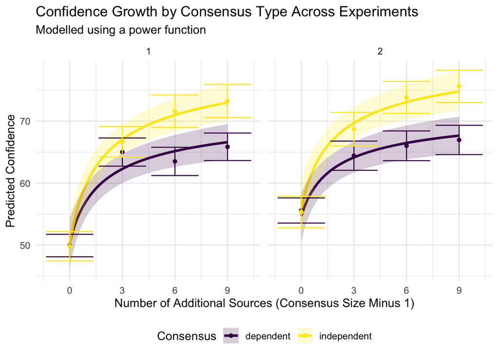

```r
plot <- d_predictions %>%
  ggplot(aes(x = additional_sources, color = consensus, fill = consensus)) +
  geom_line(size = 1.2, aes(y = Estimate)) +
  geom_ribbon(aes(ymin = Q2.5, ymax = Q97.5, y = Estimate), alpha = 0.2, color = NA) +
  geom_point(data = d_empirical_summ, aes(y = mean))+
  geom_errorbar(data = d_empirical_summ, aes(ymin = mean - se, ymax = mean + se))+
  facet_grid(~experiment)+
  labs(
    x = "Number of Additional Sources (Consensus Size Minus 1)",
    y = "Predicted Confidence",
    title = paste0("Confidence Growth by Consensus Type Across Experiments"),
    subtitle = "Modelled using a power function",
    color = "Consensus",
    fill = "Consensus"
  ) +
  scale_fill_viridis_d(option = "D")+
  scale_colour_viridis_d(option = "D")+
  scale_x_continuous(breaks = seq(0,9,3))+
  theme_minimal(base_size = 12)+
  theme(legend.position = "bottom")

plot
```

```r
ggsave(plot = plot, filename = here(paste0("plots/fe-brms-power-fit.jpg")), width = 7, height = 4)
```

Seems like it does pretty well! I’ve also had a look at some other similar functions, like log or exponential functions, and found that log & power fit similarly better than exponential, but I chose power because I find the parameters more interperetable.

Now that we know the model fits well, and we can see that an independent consensus clearly results in greater increases in confidence as a function of the number of sources, we can try and figure out what is driving these differences. Specifically, whether it is rate of increase, asymptote, or both.

# Compare parameters across conditions

The table below shows the absolute means an 95% credible differences between parameters, as well as the *relative* means and 95% credible differences between parameters across independence conditions. The relative differences were calculated because the parameters are on different scales (small differences in rate result in big differences in shape of the curve), so this allows us to see by what % is the parameter in the independent condition > than the equivalent in the dependent condition.

```r
param_contrasts_summary <- NULL
param_contrasts_long <- NULL
for (exp in experiments){

fit <- fits[[exp]]
  # Extract draws
draws <- as_draws_df(fit)

# 2. Helper to extract and transform parameters
get_param_contrasts <- function(draws, param_name) {
  intercept <- draws[[paste0("b_", param_name, "_Intercept")]]
  condition_effect <- draws[[paste0("b_", param_name, "_consensusindependent")]]

  dep <- exp(intercept)
  indep <- exp(intercept + condition_effect)

  tibble(
    parameter = param_name,
    dep = dep,
    indep = indep,
    abs_diff = indep - dep,
    rel_diff = (indep - dep) / dep
  )
}

# 3. Individual parameter contrasts
log_params <- c("rate", "increase", "start")
param_contrasts <- bind_rows(lapply(log_params, function(p) get_param_contrasts(draws, p)))

# 4. Derived "true" asymptote = start + increase
asymptote_dep <- exp(draws$b_start_Intercept) + exp(draws$b_increase_Intercept)
asymptote_indep <- exp(draws$b_start_Intercept + draws$b_start_consensusindependent) +
  exp(draws$b_increase_Intercept + draws$b_increase_consensusindependent)

param_contrasts <- bind_rows(
  param_contrasts,
  tibble(
    parameter = "asymptote",
    dep = asymptote_dep,
    indep = asymptote_indep,
    abs_diff = asymptote_indep - asymptote_dep,
    rel_diff = (asymptote_indep - asymptote_dep) / asymptote_dep
  )
)

# 5. Summarise posterior contrasts
param_contrasts_summary_exp <- param_contrasts %>%
  group_by(parameter) %>%
  summarise(
    mean_dep = mean(dep),
    mean_indep = mean(indep),
    mean_abs_diff = mean(abs_diff),
    ci_abs_lower = quantile(abs_diff, 0.025),
    ci_abs_upper = quantile(abs_diff, 0.975),
    prob_indep_gt_dep = mean(abs_diff > 0),

    mean_rel_diff = mean(rel_diff),
    ci_rel_lower = quantile(rel_diff, 0.025),
    ci_rel_upper = quantile(rel_diff, 0.975)
  ) %>%
  arrange(match(parameter, c("rate", "increase", "start", "asymptote")))

param_contrasts_summary[[exp]] <- param_contrasts_summary_exp %>%
  filter(parameter != "increase")

param_contrasts_long_exp <- param_contrasts %>%
  pivot_longer(
    cols = c(dep, indep),
    names_to = "consensus",
    values_to = "value"
  ) %>%
  mutate(experiment = exp)

param_contrasts_long <- bind_rows(param_contrasts_long, param_contrasts_long_exp)
}

print("Experiment 1")
```

```
[1] "Experiment 1"
```

```r
param_contrast_summ_e1 <- param_contrasts_summary[[1]]
param_contrast_summ_e1[,c(1:3,8:10)]
```

```
# A tibble: 3 × 6
  parameter mean_dep mean_indep mean_rel_diff ci_rel_lower ci_rel_upper
  <chr>        <dbl>      <dbl>         <dbl>        <dbl>        <dbl>
1 rate         0.518      0.539      0.0437       -0.297          0.478
2 start       50.3       50.2       -0.000185     -0.109          0.119
3 asymptote   74.2       83.5        0.126         0.00592        0.277
```

```r
print("Probability that parameter in independent condition > dependent condition:")
```

```
[1] "Probability that parameter in independent condition > dependent condition:"
```

```r
param_contrast_summ_e1[,c(1,7)]
```

```
# A tibble: 3 × 2
  parameter prob_indep_gt_dep
  <chr>                 <dbl>
1 rate                  0.554
2 start                 0.489
3 asymptote             0.982
```

```r
print("Experiment 2")
```

```
[1] "Experiment 2"
```

```r
param_contrast_summ_e2 <- param_contrasts_summary[[2]]
param_contrast_summ_e1[,c(1:3,8:10)]
```

[output not shown]

```
# A tibble: 3 × 6
  parameter mean_dep mean_indep mean_rel_diff ci_rel_lower ci_rel_upper
  <chr>        <dbl>      <dbl>         <dbl>        <dbl>        <dbl>
1 rate         0.518      0.539      0.0437       -0.297          0.478
2 start       50.3       50.2       -0.000185     -0.109          0.119
3 asymptote   74.2       83.5        0.126         0.00592        0.277
```

```r
print("Probability that parameter in independent condition > dependent condition:")
```

```
[1] "Probability that parameter in independent condition > dependent condition:"
```

```r
param_contrast_summ_e2[,c(1,7)]
```

```
# A tibble: 3 × 2
  parameter prob_indep_gt_dep
  <chr>                 <dbl>
1 rate                  0.532
2 start                 0.652
3 asymptote             0.991
```

The plots below illustrate this more clearly.

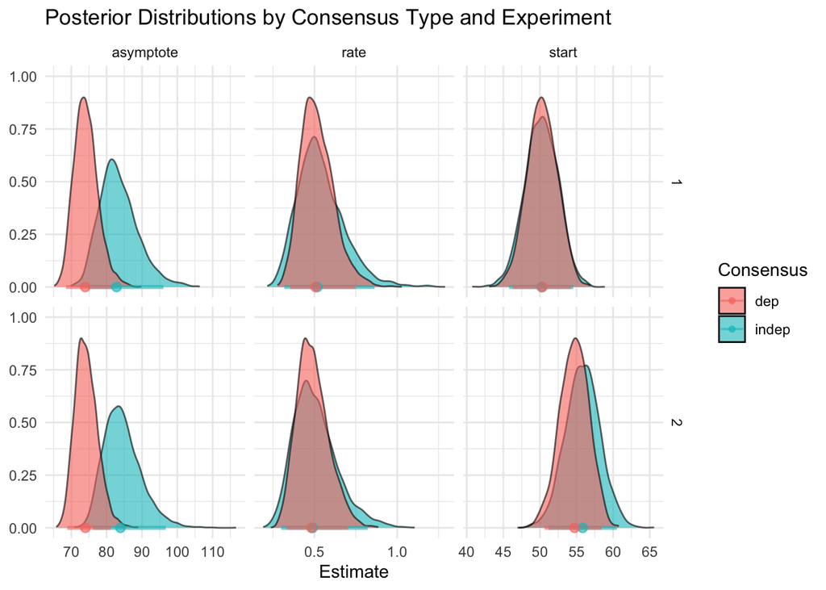

```r
# Plot

param_contrasts_long %>%
  filter(parameter != "increase") %>% # remove increase parameter because it is basically the same as asymptote
ggplot(aes(x = value, colour = consensus, fill = consensus)) +
  stat_halfeye(alpha = 0.6, slab_linewidth = 0.5, slab_color = "black",  normalize = "xy", .width = .95) +
  facet_wrap(~parameter, scales = "free_x")+
  facet_grid(experiment ~ parameter , scales = "free") +
  theme_minimal() +
  labs(
    title = "Posterior Distributions by Consensus Type and Experiment",
   # subtitle = paste0("Experiment ", experiment),
    x = "Estimate",
    y = NULL,
    fill = "Consensus",
    color = "Consensus"
  )
```

Looks like pretty clear evidence that differences independence are being driven by differences in the asymptote: the maximum effect of source number on confidence for each independence condition, not rate. This suggests that even if you continued to increase the number of dependent sources, a dependent consensus will not be more convincing than an independent consensus, so long as the independent consensus has at least around 10 sources. An interesting and falsifiable prediction that could be tested in future work, showing one example of why I think this approach is useful.

It is also worth noting that even though there are no limits placed on the highest possible asymptote that the model could have estimated, it doesn’t really seem to go above 100, which is the maximum of the scale. It is also good to see that the start parameter — which is the effect of independence at baseline (1:1) is basically the same for both types of consensus in both experiments.

# Other robustness checks I can do

If we wanted to follow this up further, I could also do a model comparison version of this analysis, where I fit different versions of this model, some where I allow certain parameters to vary across consensus conditions, and others where I don’t, to see whether allowing a parameter to vary improves its performance. This is basically another way of getting at the same question, but it’s good to make sure both methods converge on the same conclusion.